# CS 422 - Homework 9

Imaduddin Sheikh

###### Due Date: Sunday May 01, 2022, 11:59:59 PM Chicago Time

### 2. Practicum Problems

### 2.1. DBScan

```r
library("factoextra")
```

```r
library("ggplot2")
library("dplyr")
library("cluster")
library("fpc")
library("dbscan")
setwd("~/Homework 9")
s1.df <- read.csv("s1.csv")
```

```r
s1.df
```

| x | y |
| --- | --- |
| 664159 | 550946 |
| 665845 | 557965 |
| 597173 | 575538 |
| 618600 | 551446 |
| 635690 | 608046 |
| 588100 | 557588 |
| 582015 | 546191 |
| 604678 | 574577 |
| 572029 | 518313 |
| 604737 | 574591 |

[output cut: 4990 more lines]

```r
summary(s1.df)
```

```
##        x                y
##  Min.   : 19835   Min.   : 51121
##  1st Qu.:320353   1st Qu.:320108
##  Median :505339   Median :526260
##  Mean   :514938   Mean   :494709
##  3rd Qu.:786229   3rd Qu.:713714
##  Max.   :961951   Max.   :970756
```

### Part 2.1(a)

I think it is necessary to standardize the data. According to the summary obtained from the s1 data set. The range of the values in both attributes is very high so it would take some time for the DBScan clustering algorithm to converge if not standardized.

### Part 2.1(b)

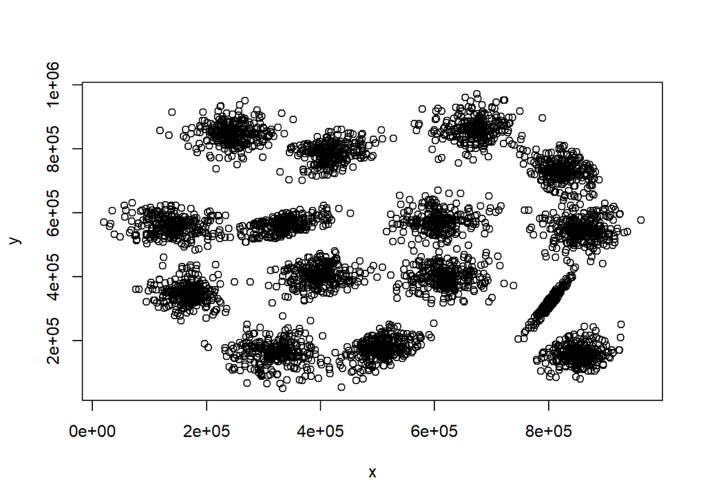

```r
plot(s1.df)
```

According to the graph plotted above, I can observe **15** clusters. The 10 clusters observed in the left and middle are easily separable. However, the 5 clusters on the right are not clearly easily separable(excluding the one at the bottom-right corner of the scatter plot). I selected 15 based on my intuition.

### Part 2.1(c)

### Part 2.1(c)(i)

```r
scaled.df <- scale(s1.df)
```

```r
summary(scaled.df)
```

```
##        x                  y
##  Min.   :-2.02524   Min.   :-1.8809
##  1st Qu.:-0.79596   1st Qu.:-0.7403
##  Median :-0.03927   Median : 0.1338
##  Mean   : 0.00000   Mean   : 0.0000
##  3rd Qu.: 1.10973   3rd Qu.: 0.9286
##  Max.   : 1.82853   Max.   : 2.0185
```

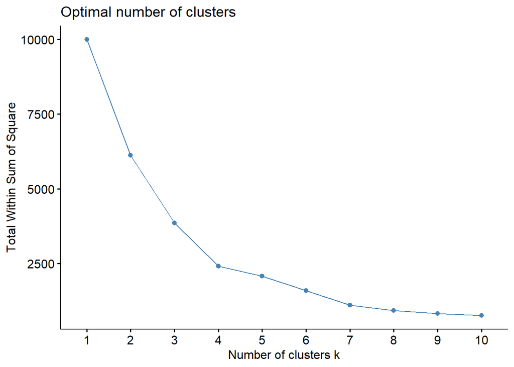

```r
fviz_nbclust(scaled.df, kmeans, method="wss")
```

### Part 2.1(c)(ii)

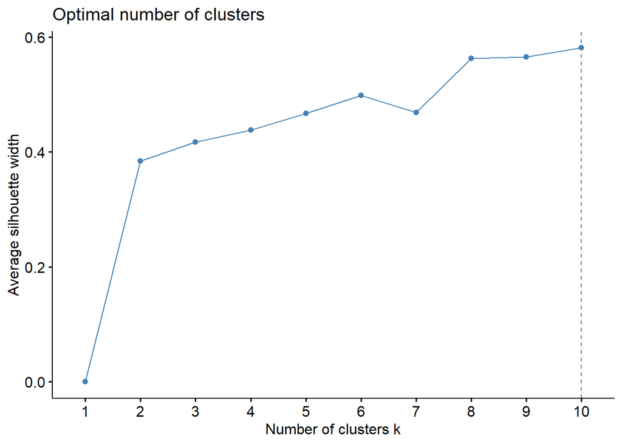

```r
fviz_nbclust(scaled.df, kmeans, method="silhouette")
```

### Part 2.1(c)(iii)

After taking both the WSS and Silhouette graphs into account, **8** would be a good number for clustering. The average silhouette value at k=8 is high enough such that the values k>8 have minimal change on the average silhouette value. Similarly, the total within SS value at k>8 doesn’t change significantly.

### Part 2.1(d)

### Part 2.1(d)(i)

```r
k <- kmeans(scaled.df, centers=8, nstart=55)
```

```r
k
```

```
## K-means clustering with 8 clusters of sizes 642, 676, 680, 630, 380, 691, 652, 649
##
## Cluster means:
##            x           y
## 1  1.2782790 -1.08938887
## 2 -0.5980817 -0.05838550
## 3 -1.4786063 -0.16825649
## 4  0.3944067 -0.06265662
## 5  0.6645440  1.53791227
## 6 -0.4059339 -1.38241962
## 7 -0.7695851  1.37280014
## 8  1.3410896  0.56783350
##
## Clustering vector:
##    [1] 4 4 4 4 4 4 4 4 4 4 4 4 4 4 4 4 4 4 4 4 4 4 4 4 4 4 4 4 4 4 4 4 4 4 4 4 4
```

[output cut: 145 more lines]

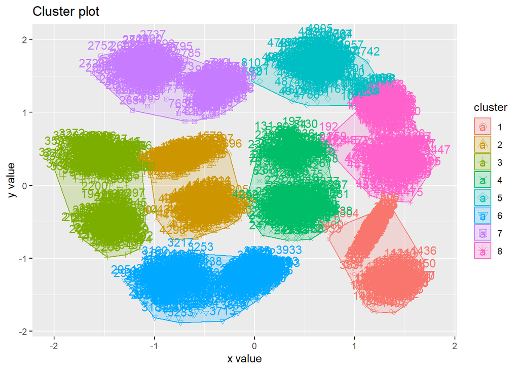

```r
fviz_cluster(k, data=scaled.df)
```

### Part 2.1(d)(ii)

The K-Means clustering algorithm has clustered, for the most part, 2 nearest high-density portions of the graph into a single cluster. However, the blue cluster on the top-right border of the plot doesn’t meet the above statement, and cuts a portion of the graph that has high density(the part that should have been in purple cluster).

### Part 2.1(e)

### Part 2.1(e)(i)

MinPts = **6** should be a reasonable value. Even though the data set has 2 dimensions, MinPts = 6 will be an ideal parameter due to spread of points on the edges of some clusters.

### Part 2.1(e)(ii)

```r
epsilon <- seq(0.01, 0.22, 0.01)
avg_sil_width <- c()
eps.array <- c()
```

```r
for (ep in epsilon) {
  eps.array <- append(eps.array, ep)
  db <- fpc::dbscan(scaled.df, eps = ep, MinPts = 4)
  avg_sil_width <- append(avg_sil_width, mean(silhouette(db$cluster, dist(scaled.df))[,"sil_width"]))
  rm(db)
}
```

```r
eps.sil.df <- data.frame(eps.array, avg_sil_width)
eps.sil.df
```

| eps.array | avg_sil_width |
| --- | --- |
| 0.01 | -0.61947058 |
| 0.02 | -0.24754669 |
| 0.03 | -0.07367488 |
| 0.04 | 0.10787943 |
| 0.05 | 0.24252916 |
| 0.06 | 0.41830900 |
| 0.07 | 0.51198813 |
| 0.08 | 0.60527323 |
| 0.09 | 0.40738577 |
| 0.10 | 0.48642847 |

[output cut: 12 more lines]

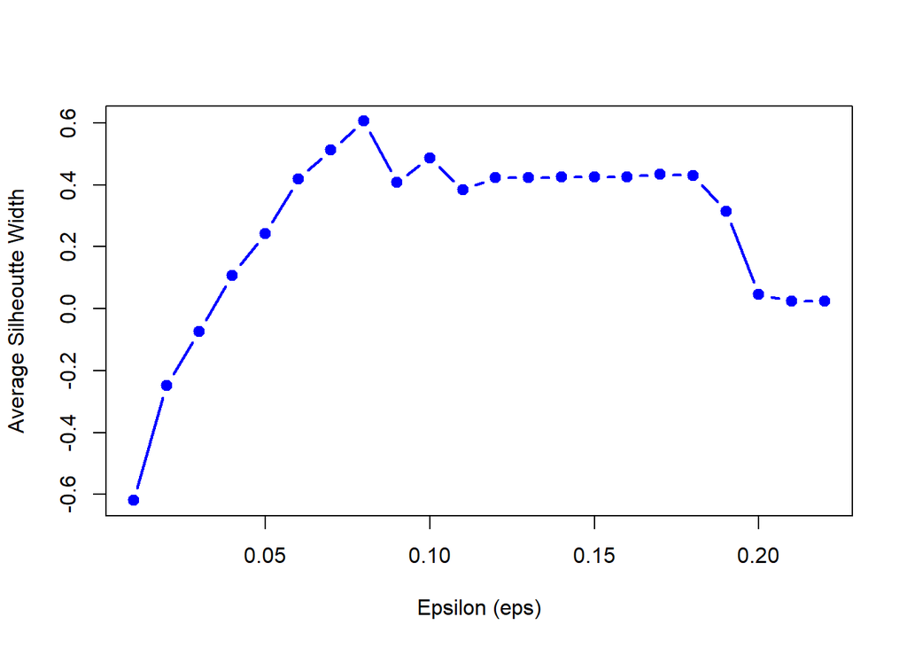

```r
plot(eps.sil.df,
        xlab="Epsilon (eps)",
        ylab="Average Silheoutte Width", type="b", col="blue", lwd=2, pch=19)
```

```r
eps.sil.df[which.max(eps.sil.df[,"avg_sil_width"]),]
```

|  | eps.array | avg_sil_width |
| --- | --- | --- |
| 8 | 0.08 | 0.6052732 |

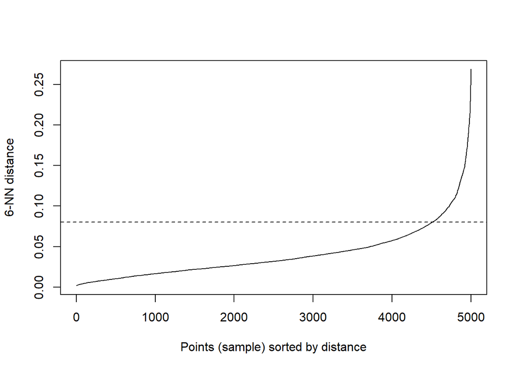

```r
dbscan::kNNdistplot(scaled.df, k =  6)
abline(h = 0.08, lty = 2)
```

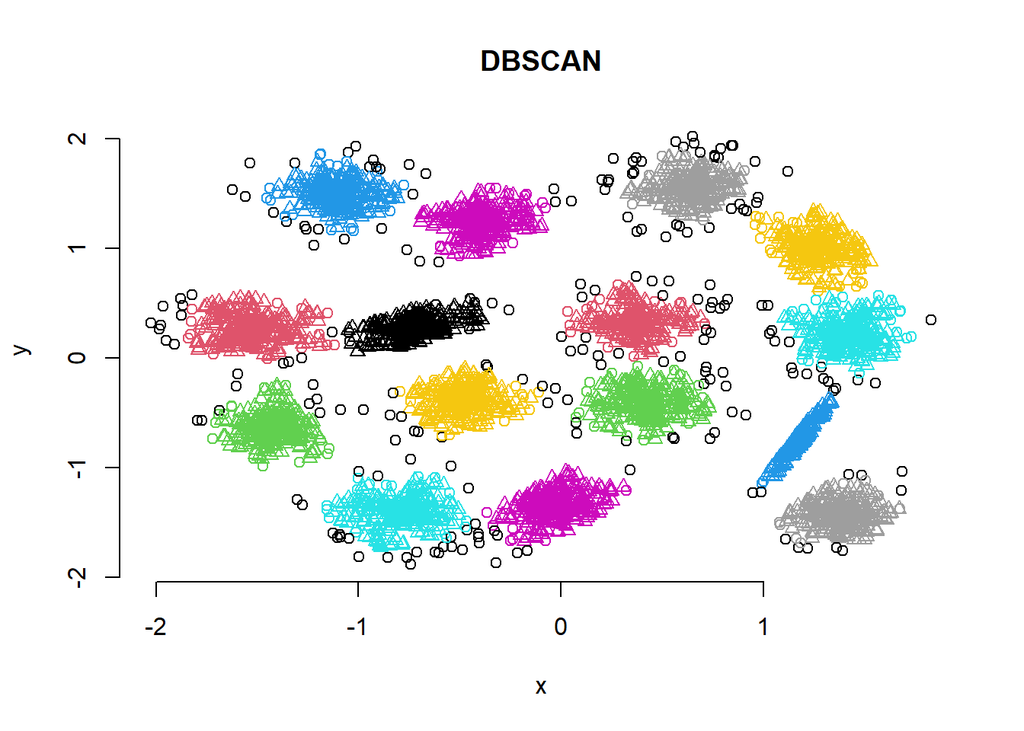

```r
db <- fpc::dbscan(scaled.df, eps = 0.08, MinPts = 6)
plot(db, scaled.df, main = "DBSCAN", frame = FALSE)
```

******

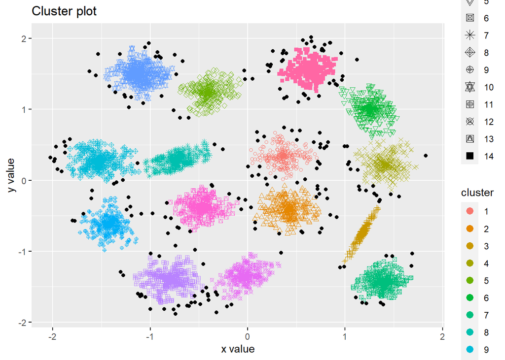

```r
fviz_cluster(db, scaled.df, stand = FALSE, ellipse = F, geom = "point")
```

```r
db
```

```
## dbscan Pts=5000 MinPts=6 eps=0.08
##          0   1   2   3   4   5   6   7   8   9  10  11  12  13  14  15
## border 208  14  14   2  18  11  18   8   6  14  14  16  16   7  11   6
## seed     0 259 307 308 316 297 301 308 319 318 310 304 296 338 327 309
## total  208 273 321 310 334 308 319 316 325 332 324 320 312 345 338 315
```

At minPts = **6**, eps = **0.08**, there are **15** clusters.

### 2.2. Principal Component Analysis

### Part 2.2(a)

### Part 2.2(a)(i)

```r
countries.df <- read.csv("countries.csv", row.names = 1)
countries.df
```

|  | GDP | HIV | Lifeexp | Mil | Oilcons | Pop | Tel | Unempl |
| --- | --- | --- | --- | --- | --- | --- | --- | --- |
| Brazil | 8710 | 0.7 | 72.2 | 2.6 | 4.0 | 190 | 204.2 | 9.6 |
| Canada | 35370 | 0.3 | 80.3 | 1.1 | 25.1 | 33 | 622.3 | 6.4 |
| China | 7724 | 0.1 | 72.9 | 4.3 | 1.8 | 1322 | 278.4 | 4.2 |
| France | 29852 | 0.4 | 80.6 | 2.6 | 11.3 | 64 | 543.5 | 8.7 |
| Germany | 31941 | 0.1 | 79.0 | 1.5 | 11.7 | 82 | 657.8 | 7.1 |
| India | 3685 | 0.9 | 68.6 | 2.5 | 0.8 | 1130 | 44.0 | 7.8 |
| Indonesia | 4041 | 0.1 | 70.2 | 3.0 | 1.8 | 235 | 63.2 | 12.5 |
| Italy | 30199 | 0.5 | 79.9 | 1.8 | 11.8 | 58 | 430.8 | 7.0 |
| Japan | 33100 | 0.1 | 82.0 | 0.8 | 16.0 | 127 | 432.8 | 4.1 |
| Mexico | 10570 | 0.3 | 75.6 | 0.5 | 6.6 | 109 | 182.7 | 3.2 |

[output cut: 5 more lines]

```r
summary(countries.df)
```

```
##       GDP             HIV            Lifeexp           Mil
##  Min.   : 3685   Min.   :0.1000   Min.   :65.90   Min.   :0.500
##  1st Qu.: 9640   1st Qu.:0.1000   1st Qu.:72.55   1st Qu.:1.350
##  Median :27418   Median :0.3000   Median :78.00   Median :2.500
##  Mean   :22296   Mean   :0.4133   Mean   :76.06   Mean   :2.253
##  3rd Qu.:31832   3rd Qu.:0.6500   3rd Qu.:79.85   3rd Qu.:2.700
##  Max.   :43369   Max.   :1.1000   Max.   :82.00   Max.   :4.300
##     Oilcons           Pop              Tel            Unempl
##  Min.   : 0.80   Min.   :  33.0   Min.   : 44.0   Min.   : 2.90
##  1st Qu.: 5.25   1st Qu.:  59.5   1st Qu.:241.3   1st Qu.: 4.15
##  Median :11.30   Median : 109.0   Median :432.8   Median : 6.60
##  Mean   :10.91   Mean   : 262.8   Mean   :391.3   Mean   : 6.42
##  3rd Qu.:15.10   3rd Qu.: 212.5   3rd Qu.:550.4   3rd Qu.: 7.95
##  Max.   :25.10   Max.   :1322.0   Max.   :657.8   Max.   :12.50
```

### Part 2.2(a)(ii)

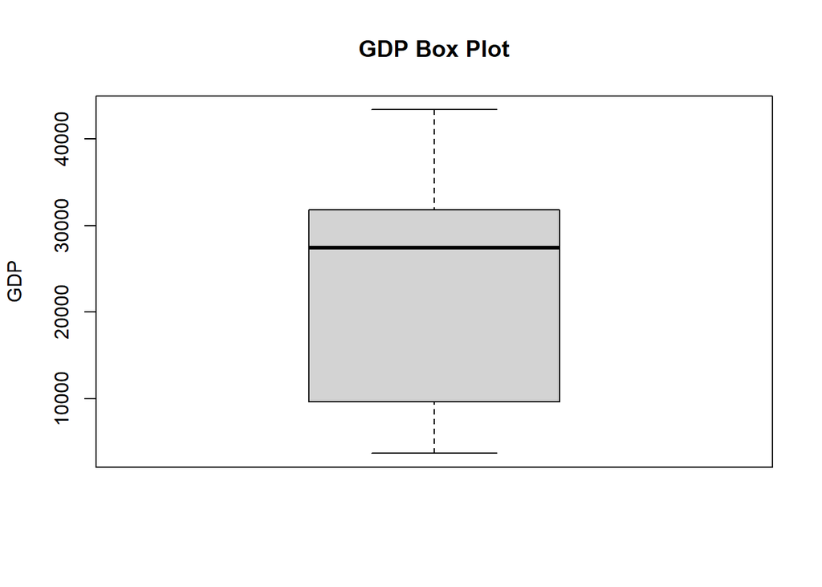

```r
n <- 1
boxplot(countries.df[,n], ylab = colnames(countries.df)[n], main = paste0(colnames(countries.df)[n], " Box Plot"))
```

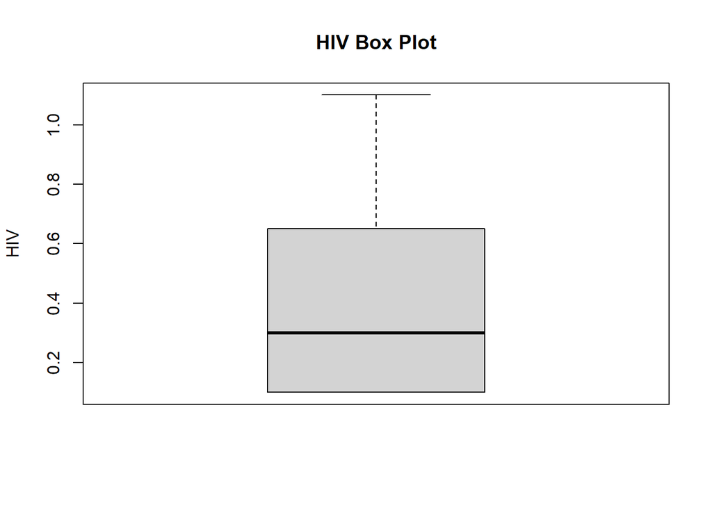

```r
n <- 2
boxplot(countries.df[,n], ylab = colnames(countries.df)[n], main = paste0(colnames(countries.df)[n], " Box Plot"))
```

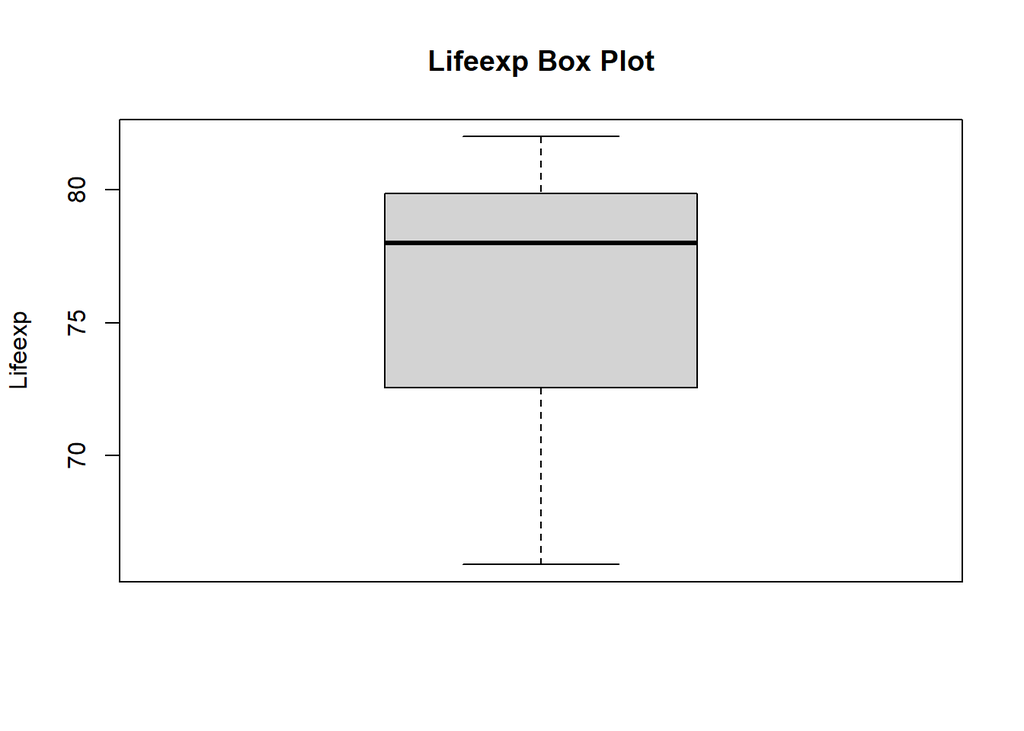

```r
n <- 3
boxplot(countries.df[,n], ylab = colnames(countries.df)[n], main = paste0(colnames(countries.df)[n], " Box Plot"))
```

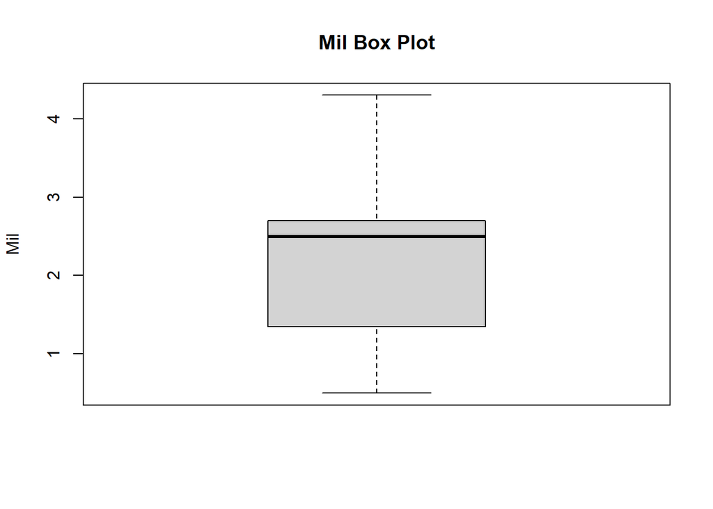

```r
n <- 4
boxplot(countries.df[,n], ylab = colnames(countries.df)[n], main = paste0(colnames(countries.df)[n], " Box Plot"))
```

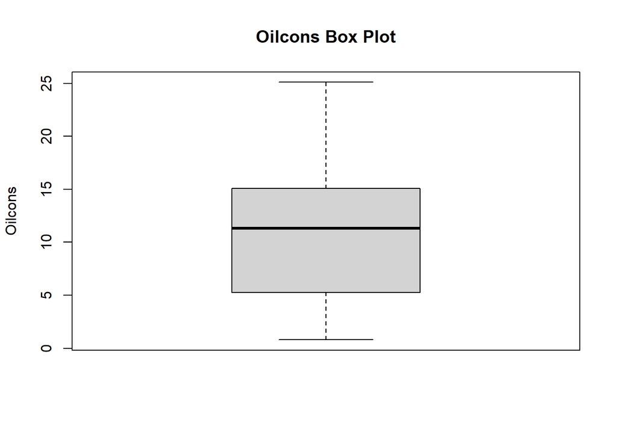

```r
n <- 5
boxplot(countries.df[,n], ylab = colnames(countries.df)[n], main = paste0(colnames(countries.df)[n], " Box Plot"))
```

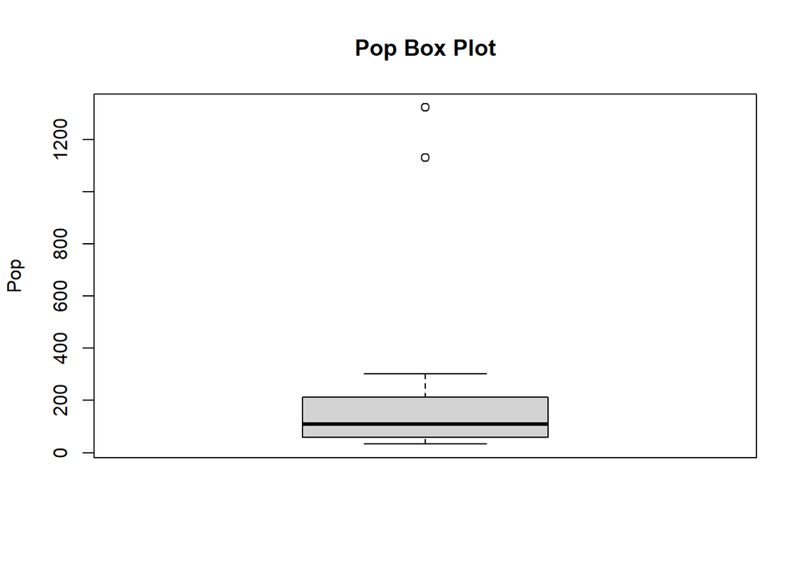

```r
n <- 6
boxplot(countries.df[,n], ylab = colnames(countries.df)[n], main = paste0(colnames(countries.df)[n], " Box Plot"))
```

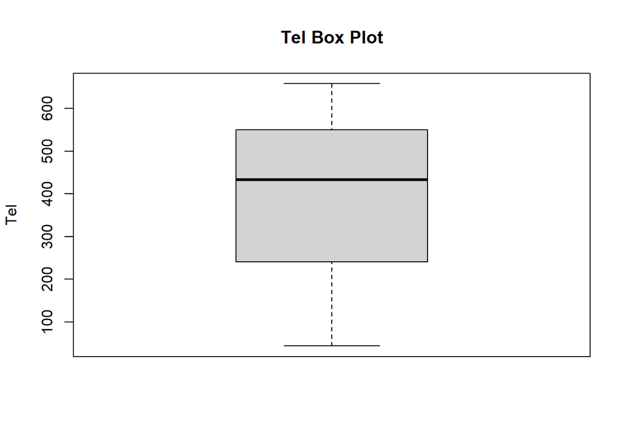

```r
n <- 7
boxplot(countries.df[,n], ylab = colnames(countries.df)[n], main = paste0(colnames(countries.df)[n], " Box Plot"))
```

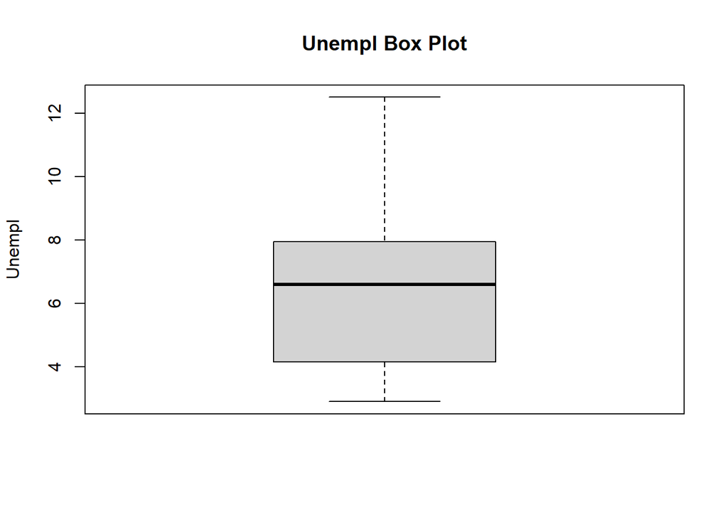

```r
n <- 8
boxplot(countries.df[,n], ylab = colnames(countries.df)[n], main = paste0(colnames(countries.df)[n], " Box Plot"))
```

The two outliers in the Pop box plot correspond to India and China. The population of the two countries is significantly high as opposed to other countries.

### Part 2.2(b)

### Part 2.2(b)(i)

```r
pca <- prcomp(countries.df, center = TRUE, scale = TRUE)
```

```r
summary(pca)
```

```
## Importance of components:
##                           PC1    PC2    PC3    PC4     PC5     PC6     PC7
## Standard deviation     2.0605 1.1379 1.0170 0.8690 0.59319 0.41733 0.33233
## Proportion of Variance 0.5307 0.1618 0.1293 0.0944 0.04398 0.02177 0.01381
## Cumulative Proportion  0.5307 0.6925 0.8218 0.9162 0.96022 0.98199 0.99580
##                           PC8
## Standard deviation     0.1833
## Proportion of Variance 0.0042
## Cumulative Proportion  1.0000
```

There is **no component** that explains at least 90% of variance. The highest proportion of a variance from all the components is 53.1%.

### Part 2.2(b)(ii)

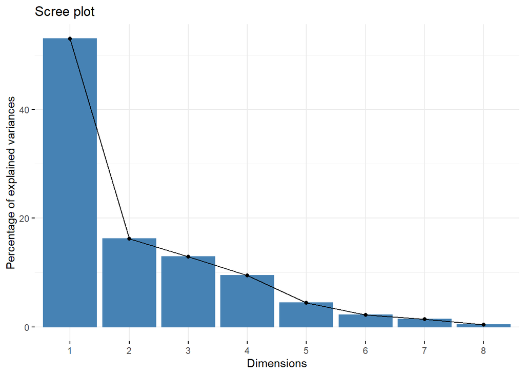

```r
library(factoextra)
fviz_eig(pca)
```

### Part 2.2(b)(iii)

According to the scree plot, 5 principal components should do the trick for feature reduction.

### Part 2.2(c)

```r
pca
```

```
## Standard deviations (1, .., p=8):
## [1] 2.0604984 1.1378752 1.0170179 0.8690036 0.5931903 0.4173294 0.3323291
## [8] 0.1833373
##
## Rotation (n x k) = (8 x 8):
##                PC1         PC2          PC3         PC4         PC5         PC6
## GDP      0.4560268  0.06362084 -0.271093835 -0.05442480  0.14947678 -0.08002969
## HIV     -0.1934368 -0.32800239 -0.694218852  0.48404674  0.19548002 -0.23804695
## Lifeexp  0.4407804  0.01452102  0.187653505 -0.14486052  0.44812657 -0.24828417
## Mil     -0.1964834  0.56706336 -0.480082473 -0.41625346 -0.32517176 -0.05002767
## Oilcons  0.4275287  0.03644676 -0.320454603  0.04650622  0.07839373  0.78889952
## Pop     -0.3150143  0.54189871  0.006639875  0.07981396  0.72635243  0.05264696
## Tel      0.4423016  0.14093180 -0.200094388 -0.11206139 -0.07267202 -0.49436031
## Unempl  -0.2099599 -0.50174771 -0.190006038 -0.73986102  0.30639110  0.05705115
##                PC7         PC8
## GDP      0.1466324  0.81319670
## HIV      0.1456698 -0.15052276
## Lifeexp  0.5683508 -0.40474473
## Mil      0.3340639 -0.12747214
## Oilcons -0.1184137 -0.26173851
## Pop     -0.2583224  0.06006144
## Tel     -0.6471483 -0.25186858
## Unempl  -0.1520024  0.02084195
```

### Part 2.2(c)(i)

PC1 has a positive correlation with GDP, Lifeexp, Oilcons, and Tel,while having negatively correlation with HIV, Mil, Pop, and Unempl. GDP, Lifeexp, Oilcons, and Tel all are high values, being close to 0.45. My expectation from PC1 is that it indicates that a country with good economy will have a good, and healthy quality of life despite having a comparatively lower population.. The negative value of HIV and positive value of Lifeexp indicate good health. I think that high positive values of Oilcons and Tel could mean people are more readily able to fulfill necessities of life like personal travel, and availability of internet/information. And high GDP also tends to lower unemployment.

### Part 2.2(c)(ii)

PC2 is positively correlated with GDP, Lifeexp, Mil, Oilcons, Pop, and Tel. It is negatively correlated with HIV, and Unempl. Basing on the values and correlations, I expect PC2 to be a more generalizable form of PC1 where it indicates that low HIV(more healthy population) in turn leads to higher population, while also indicating how a country with high military spending percentage interestingly tends to have low unemployment. It could indicate that military spending percentage does have a positive role to play in improving population’s quality of life and health.

### Part 2.2(d)

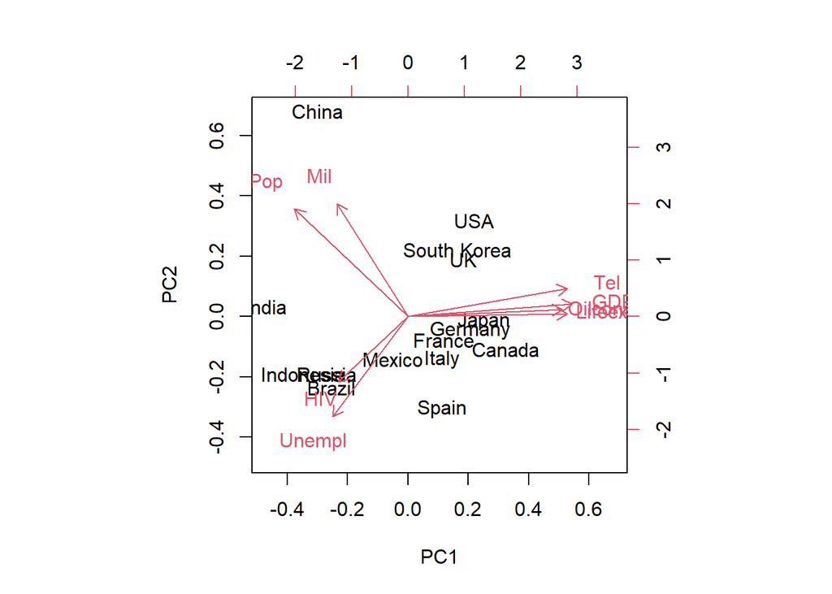

```r
biplot(pca, choices = 1:2)
```

### Part 2.2(d)(i)

```r
pca$x[c("Brazil", "UK", "Japan"),1:2]
```

```
##              PC1         PC2
## Brazil -2.037017 -1.03998472
## UK      1.456991  0.83445072
## Japan   2.013116 -0.05735491
```

### Part 2.2(d)(ii)

```r
countries.df
```

|  | GDP | HIV | Lifeexp | Mil | Oilcons | Pop | Tel | Unempl |
| --- | --- | --- | --- | --- | --- | --- | --- | --- |
| Brazil | 8710 | 0.7 | 72.2 | 2.6 | 4.0 | 190 | 204.2 | 9.6 |
| Canada | 35370 | 0.3 | 80.3 | 1.1 | 25.1 | 33 | 622.3 | 6.4 |
| China | 7724 | 0.1 | 72.9 | 4.3 | 1.8 | 1322 | 278.4 | 4.2 |
| France | 29852 | 0.4 | 80.6 | 2.6 | 11.3 | 64 | 543.5 | 8.7 |
| Germany | 31941 | 0.1 | 79.0 | 1.5 | 11.7 | 82 | 657.8 | 7.1 |
| India | 3685 | 0.9 | 68.6 | 2.5 | 0.8 | 1130 | 44.0 | 7.8 |
| Indonesia | 4041 | 0.1 | 70.2 | 3.0 | 1.8 | 235 | 63.2 | 12.5 |
| Italy | 30199 | 0.5 | 79.9 | 1.8 | 11.8 | 58 | 430.8 | 7.0 |
| Japan | 33100 | 0.1 | 82.0 | 0.8 | 16.0 | 127 | 432.8 | 4.1 |
| Mexico | 10570 | 0.3 | 75.6 | 0.5 | 6.6 | 109 | 182.7 | 3.2 |

[output cut: 5 more lines]

```r
pca
```

```
## Standard deviations (1, .., p=8):
## [1] 2.0604984 1.1378752 1.0170179 0.8690036 0.5931903 0.4173294 0.3323291
## [8] 0.1833373
##
## Rotation (n x k) = (8 x 8):
##                PC1         PC2          PC3         PC4         PC5         PC6
## GDP      0.4560268  0.06362084 -0.271093835 -0.05442480  0.14947678 -0.08002969
## HIV     -0.1934368 -0.32800239 -0.694218852  0.48404674  0.19548002 -0.23804695
## Lifeexp  0.4407804  0.01452102  0.187653505 -0.14486052  0.44812657 -0.24828417
## Mil     -0.1964834  0.56706336 -0.480082473 -0.41625346 -0.32517176 -0.05002767
## Oilcons  0.4275287  0.03644676 -0.320454603  0.04650622  0.07839373  0.78889952
## Pop     -0.3150143  0.54189871  0.006639875  0.07981396  0.72635243  0.05264696
## Tel      0.4423016  0.14093180 -0.200094388 -0.11206139 -0.07267202 -0.49436031
## Unempl  -0.2099599 -0.50174771 -0.190006038 -0.73986102  0.30639110  0.05705115
##                PC7         PC8
## GDP      0.1466324  0.81319670
## HIV      0.1456698 -0.15052276
## Lifeexp  0.5683508 -0.40474473
## Mil      0.3340639 -0.12747214
## Oilcons -0.1184137 -0.26173851
## Pop     -0.2583224  0.06006144
## Tel     -0.6471483 -0.25186858
## Unempl  -0.1520024  0.02084195
```

Brazil has PC1 = -2.04 and PC2 = -1.04. This makes sense to me for PC1 because Brazil has a low GDP, and one can see the effects by observing relatively lower Lifeexp, Oilcons, and Tel, coupled with high unemployment rate. Low population and military spending percentage and high unemployment contribute to the negative value of PC2.

Japan has PC1 = 2.01 and PC2 = -0.0574. Japan has a very high GDP, Lifeexp, Oilcons, and Tel, in turn resulting to a significantly high positive value for PC1 that we see. However, the low Mil and Pop, and at the same time, a low unemployment rate result in a pretty low(magnitude-wise) and negative value for PC2.

UK has PC1 = 1.46 and PC2 = 0.8345. This makes sense because UK has a high GDP, Lifeexp, Tel but OilCons is quite low giving a moderate and positive for PC1. UK also has low Unempl, HIV,and a very high Mil. Because it has a low population, the PC2 value is positive, and low magnitude-wise.